# IE425-HW4

Eda Kocakarin & Yusuf Ulucoban - IE425 - Spring 2022

2022-05-30

East-West Airlines is trying to learn more about its customers. Key issues are their flying patterns, earning and use of frequent flyer rewards, and use of the airline credit card. The task is to identify customer segments via clustering. The file EastWestAirlines.xlsx contains information on 4000 passengers who belong to an ariline’s frequent flier program. For each passenger the data include information on their mileage history and on different ways they accrued or spent miles in the last year. The goal is to try to identify clusters of passengers that have similar charactersitics for the purpose of targeting different segments for different types of mileage offers.

### a. Apply hierarchical clustering with Euclidean distance and complete linkage. How many clusters appear to be appropriate when the silhoutte index is used?

First of all, scaling all attributes is important to compare each attributes. With scaled attributes, hierarchical clustering with Euclidean distance and complete linkage applied.

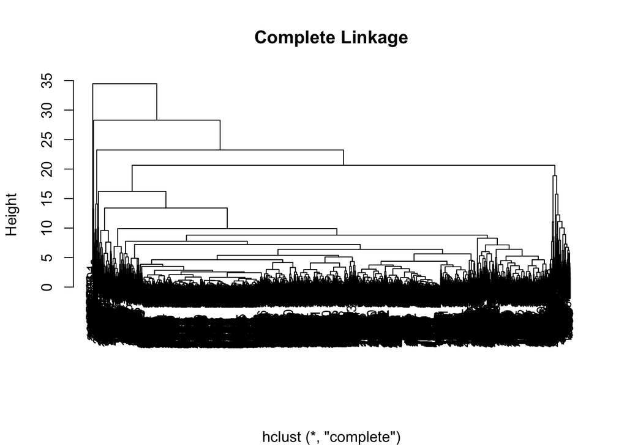

```r
X=data.frame(scale(air[-1]))
air1=data.frame(air[,-c(1)])
#look at scaled
dist1=dist(X,method="euclidean")
hc.complete=hclust(dist1, method="complete")
plot(hc.complete,main="Complete Linkage", xlab="", cex=.9)
```

Silhoutte index is calculated for k=2 to k=10, highest silhoutte index equals to 0.81 which is in 2 cluster as you can see below.

```r
silh=c()
for (k in 2:10){
 kume=cutree(hc.complete,k=k)
 X_sil=silhouette(kume, dist1)
 silh[k-1]=mean(X_sil[,3])
}

silh=data.frame(k=2:10,silh)
silh
```

```
##    k      silh
## 1  2 0.8111134
## 2  3 0.7760836
## 3  4 0.5985728
## 4  5 0.5625738
## 5  6 0.5404242
## 6  7 0.5418820
## 7  8 0.5354665
## 8  9 0.5313342
## 9 10 0.4150506
```

Let’s look silhoutte index with 2 cluster in detail.

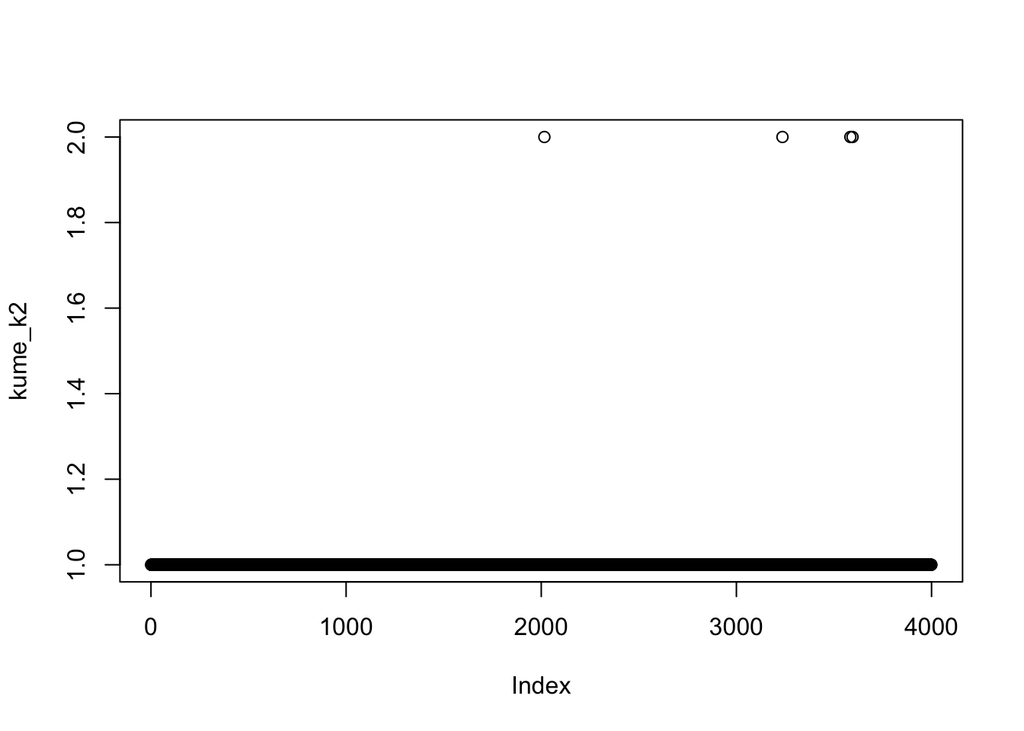

```r
#2 küme
kume_k2=cutree(hc.complete,k=2)
plot(kume_k2)
```

```r
table(kume_k2)
```

```
## kume_k2
##    1    2
## 3995    4
```

### b. Compare the cluster centroids to characterize the different clusters and try to give each cluster a label.

```r
library(scales)
clust.centroid = function(i, dat, clusters) {
    ind = (clusters == i)
    colMeans(dat[ind,])
}

comparison = sapply(unique(kume_k2), clust.centroid, air, kume_k2)
comparison = data.frame(comparison)
comparison$percentage_diff = percent((comparison[,2] - comparison[,1]) / comparison[,1])
comparison[,c(1,2)]=round(comparison[,c(1,2)],2)
comparison
```

```
##                         X1        X2 percentage_diff
## ID                 2013.70   3128.00          55.34%
## Balance           73542.86 131999.50          79.49%
## Qual_miles          143.91    347.00         141.12%
## cc1_miles             2.06      2.50          21.41%
## cc2_miles             1.01      1.00          -1.43%
## cc3_miles             1.01      1.00          -1.21%
## Bonus_miles       17096.30  65634.25         283.91%
## Bonus_trans          11.54     69.25         499.87%
## Flight_miles_12mo   440.53  19960.00       4 430.89%
## Flight_trans_12       1.33     49.25       3 615.14%
## Days_since_enroll  4120.48   2200.25         -46.60%
## Award                 0.37      1.00         170.48%
```

As it can be observed, the centroids of the clusters which is the mean of the each variable for each point in the cluster are differ from each other. The ID row can be ignored. Also, it is easy to see percentage differences between two clusters based on the first one, by the new added column.

### c. To check the stability of the clusters, remove a random 5% of the data (200 observations), and repeat the analysis. Does the same picture emerge? Use 425 as the seed.

Splitted data into 0.95 and 0.05. scaled and clustered 0.95 of dataset .

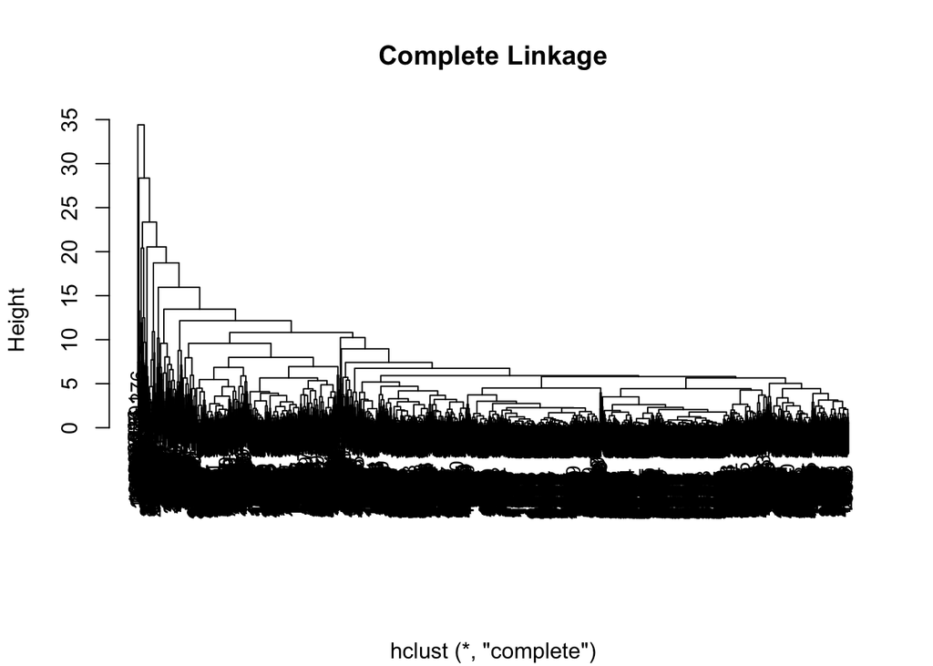

```r
set.seed(425)
split1=sample.split(air$ID,SplitRatio=0.95)

air_subset=subset(air1,split1==TRUE)

X1=data.frame(scale(air_subset))
dist1c=dist(X1,method="euclidean")
hc.complete1c=hclust(dist1c, method="complete")
plot(hc.complete1c,main="Complete Linkage", xlab="", cex=.9)
```

Silhouette index is calculated again.

```r
silh1c=c()
for (k in 2:10){
 kume1c=cutree(hc.complete1c,k=k)
 X_sil1c=silhouette(kume1c, dist1c)
 silh1c[k-1]=mean(X_sil1c[,3])
}

silh1c=data.frame(k=2:10,silh1c)
silh1c
```

```
##    k    silh1c
## 1  2 0.8359360
## 2  3 0.7787248
## 3  4 0.6756253
## 4  5 0.6667672
## 5  6 0.6558802
## 6  7 0.6285976
## 7  8 0.5927120
## 8  9 0.4924855
## 9 10 0.4919604
```

Silhoutte index increases to 0.836 in k=2. Still highest silhoutte index is in 2.

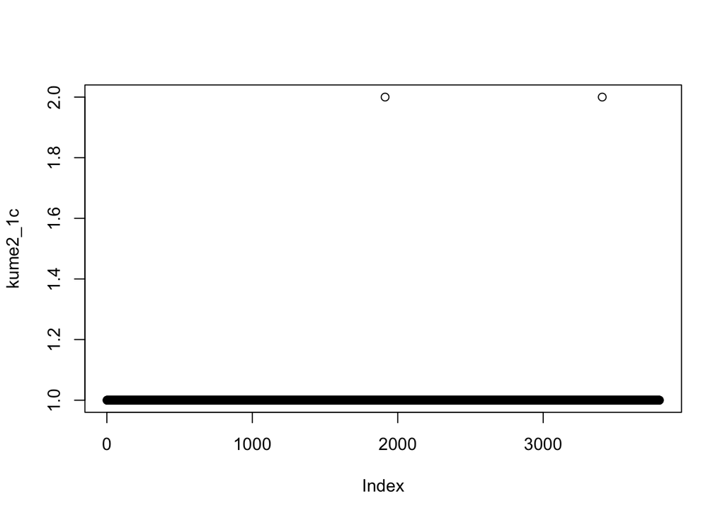

```r
#2 küme
kume2_1c=cutree(hc.complete1c,k=2)
plot(kume2_1c)
```

```r
table(kume2_1c)
```

```
## kume2_1c
##    1    2
## 3797    2
```

### d. Use k-means algorithm with different number of clusters. What is the best number of clusters using the silhoutte index?

```r
silh1d=c()
for (k in 2:10){
   set.seed(425)
   km1d=kmeans(X,centers=k,nstart=10)
 X_sil1d=silhouette(km1d$cluster, dist1)
 silh1d[k-1]=mean(X_sil1d[,3])
}

silh1d=data.frame(k=2:10,silh1d)
silh1d
```

```
##    k    silh1d
## 1  2 0.3258085
## 2  3 0.3112011
## 3  4 0.3077984
## 4  5 0.2595816
## 5  6 0.2153105
## 6  7 0.2210774
## 7  8 0.2209152
## 8  9 0.2985175
## 9 10 0.2622763
```

Continue with 2 clusters by using kmeans algorithm.

```r
library(clusterCrit)
km2=kmeans(X,centers=2, nstart=10)
```

Below you can see scaled attributes of 2 clusters and centers.

```r
km2
```

```
## K-means clustering with 2 clusters of sizes 2700, 1299
##
## Cluster means:
##      Balance Qual_miles cc1_miles   cc2_miles   cc3_miles Bonus_miles
## 1 -0.2828553 -0.0710660 -0.542459  0.01464976 -0.06086174  -0.4848087
## 2  0.5879210  0.1477122  1.127513 -0.03044985  0.12650246   1.0076855
##   Bonus_trans Flight_miles_12mo Flight_trans_12 Days_since_enroll      Award
## 1  -0.4404167        -0.1750335      -0.1947654        -0.1917576 -0.3381370
## 2   0.9154157         0.3638110       0.4048241         0.3985725  0.7028251
##
## Clustering vector:
##    [1] 1 1 1 1 2 1 2 1 2 2 1 2 1 1 1 2 2 1 2 1 2 2 1 1 1 1 1 1 2 1 2 1 2 1 1 2 1
##   [38] 1 2 1 1 2 2 2 2 2 1 1 2 1 1 1 2 1 1 1 2 1 1 2 1 1 1 1 1 2 1 2 2 2 2 2 2 1
##   [75] 2 2 1 2 2 2 1 1 1 1 1 2 1 2 1 1 1 1 2 1 2 1 1 2 1 2 2 1 1 1 1 2 2 1 2 2 2
##  [112] 2 2 1 2 2 1 2 2 1 1 2 2 2 2 2 2 2 1 2 1 1 1 2 2 2 2 2 2 1 1 1 1 2 1 1 1 2
```

[output cut: 114 more lines]

### e. Which clusters would you target for offers, and what type of offers would you target to customers in that cluster?

Lets look original version of each attribute to compare clusters and to offer personalized campaign to targeted cluster of customer.

```r
comparison1 = sapply(unique(km2$cluster), clust.centroid, air, km2$cluster)
comparison1 = data.frame(comparison1)
comparison1$percentage_diff = percent((comparison1[,2] - comparison1[,1]) / comparison1[,1])
comparison1
```

```
##                              X1             X2 percentage_diff
## ID                 2226.9788889   1573.8414165          -29.3%
## Balance           45096.3951852 132849.4549654          194.6%
## Qual_miles           89.1333333    258.3941493          189.9%
## cc1_miles             1.3125926      3.6120092          175.2%
## cc2_miles             1.0166667      1.0100077           -0.7%
## cc3_miles             1.0003704      1.0369515            3.7%
## Bonus_miles        5436.2470370  41481.4264819          663.1%
## Bonus_trans           7.3722222     20.3933795          176.6%
## Flight_miles_12mo   214.9722222    969.4672825          351.0%
## Flight_trans_12       0.6348148      2.9091609          358.3%
## Days_since_enroll  3722.5540741   4941.6651270           32.7%
## Award                 0.2070370      0.7097768          242.8%
```

Concerning Balance, bonus_miles, bonus_trans and flight_miles_12month attributes, customers in cluster2 like earning miles with flights.Therefore, cluster2 is chosen for target audience. Special campaign is determined which claims that “THE MORE FLIGHTS, THE MORE MILES”.